# Dublin Data Science Workshop on Bootstrap Methods

Mick Cooney mickcooney@gmail.com

Monday, 10 Febuary 2020

One of the main aims of statistics is to make inferences about a population using one or more random samples of data drawn from that population.

The bootstrap is part of a broader collection of techniques knows as *resampling methods* that use Monte Carlo simulation to quantify the sampling error in measuremeants.

The basic concepts of the bootstrap are simple, but further improvements require an understanding of some statistical concepts.

To motivate this approach, suppose we have a sample of 10 values and want to use this to make inferences about the underlying population. Our sample mean is $0.5$, giving us a point estimate for the population mean, but how much sample error is there?

We return to this example shortly.

# 1 Introduction to the Bootstrap

The core concept is that the bootstrap sample is to the sample as the sample is to the population.

If we denote $F$ as our sample of size $N$, we resample $F$ with replacement $R$ times and denote these bootstrap samples as $F^{*}_{r}$. Each of these bootstrap sample is the same size as the original sample, $N$.

We then calculate our statistics of interest on each of these bootstrap samples and this gives us an estimate of the uncertainty due to sample error in the value of the statistic on the original sample.

Because we are sampling with replacement, some elements of $F$ will appear multiple times and some will not appear at all. This is why we end up with a distribution of values for the statistics calculated from $F^{*}$.

To get started with the bootstrap, we will generate data from various distributions and then try to recover the parameters of those distributions.

This provides us with intuition for how the bootstrap works, and allows us to investigate the effect of things such as the distribution family and the effect of the sample size.

## 1.1 Standard Normal Distribution: $\mathcal{N(0,1)}$

We start with the standard normal distribution, $\mathcal{N(0,1)}$, and use different sample sizes for our bootstrap technique.

```r
F_stdnorm_tbl <- tibble(x = rnorm(10000, mean = 0, sd = 1))

F_stdnorm_tbl %>% glimpse()
```

```
## Observations: 10,000
## Variables: 1
## $ x <dbl> 1.3709584, -0.5646982, 0.3631284, 0.6328626, 0.4042683, -0.106124...
```

We start by using small sample sizes and investigate the bootstrap statistics. As we know the underlying parameters used to generate this data, we see how well the bootstrap method does at capturing this sample error.

We have a number of ways of calculating bootstrap statistics - we look at more sophisticated methods later but for now we use some functions provided by the `rsample` package.

### 1.1.1 Bootstrapping the Mean

#### 1.1.1.1 Sample Size $N=10$

We start with a sample size of $N=10$, and we expect the sample error to be large in this case.

```r
F_stdnorm_10_tbl <- F_stdnorm_tbl %>% head(10)

F_stdnorm_10_tbl %>% pull(x) %>% round(2)
```

```
##  [1]  1.37 -0.56  0.36  0.63  0.40 -0.11  1.51 -0.09  2.02 -0.06
```

```r
F_stdnorm_10_tbl %>% glimpse()
```

```
## Observations: 10
## Variables: 1
## $ x <dbl> 1.3709584, -0.5646982, 0.3631284, 0.6328626, 0.4042683, -0.106124...
```

The first thing we do is calculate the sample mean.

```r
F_stdnorm_10_tbl %>% pull(x) %>% mean()
```

```
## [1] 0.547297
```

So our sample mean is 0.5 and this is our point estimate for the population mean. As discussed in the introduction, how much error is there in this sample?

We now use our bootstrap samples to estimate this. We try different counts of bootstrap samples also. The `rsample` package makes this process straightforward.

```r
F_stdnorm_10_mean_tbl <- F_stdnorm_10_tbl %>%
  bootstraps(times = 10000) %>%
  mutate(btstrp_mean = map_dbl(splits, ~ .x %>% analysis() %>% pull(x) %>% mean())) %>%
  select(id, btstrp_mean)
```

We have calculated all our bootstrap means, so we now look at the effect of different bootstrap sample size for a single sample size.

```r
btstrp_stdnorm_10_mean_plots_tbl <- c(100, 500, 1000, 10000) %>%
  enframe(name = NULL, value = 'btstrp_size') %>%
  mutate(boot_data = map(btstrp_size, ~ F_stdnorm_10_mean_tbl %>% head(.x))) %>%
  unnest(boot_data)

btstrp_stdnorm_10_mean_plots_tbl %>% glimpse()
```

```
## Observations: 11,600
## Variables: 3
## $ btstrp_size <dbl> 100, 100, 100, 100, 100, 100, 100, 100, 100, 100, 100, ...
## $ id          <chr> "Bootstrap00001", "Bootstrap00002", "Bootstrap00003", "...
## $ btstrp_mean <dbl> 0.727491, 0.285368, 0.685669, 0.536998, 0.667745, 0.790...
```

Now that we have the data, we can construct a facetted histogram of the bootstrap estimates as well as produce some basic summary statistics.

```r
btstrp_stdnorm_10_mean_plots_tbl %>%
  group_by(btstrp_size) %>%
  summarise(summ = list(summary(btstrp_mean))) %>%
  unnest_wider(summ)
```

```
## # A tibble: 4 x 7
##   btstrp_size   Min. `1st Qu.` Median  Mean `3rd Qu.`  Max.
##         <dbl>  <dbl>     <dbl>  <dbl> <dbl>     <dbl> <dbl>
## 1         100 -0.109     0.401  0.564 0.577     0.774  1.22
## 2         500 -0.109     0.412  0.556 0.568     0.742  1.22
## 3        1000 -0.159     0.386  0.544 0.557     0.731  1.36
## 4       10000 -0.334     0.375  0.542 0.550     0.722  1.58
```

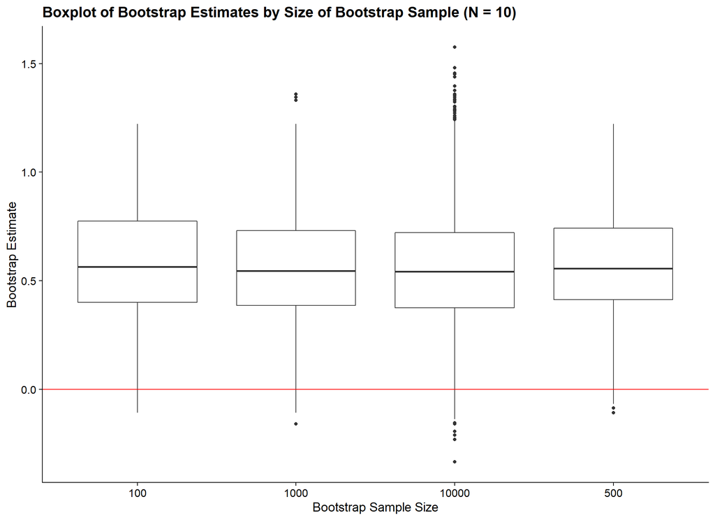

```r
ggplot(btstrp_stdnorm_10_mean_plots_tbl) +
  geom_boxplot(aes(x = vec_cast(btstrp_size, character()), y = btstrp_mean)) +
  geom_hline(aes(yintercept = 0), colour = 'red') +
  xlab("Bootstrap Sample Size") +
  ylab("Bootstrap Estimate") +
  ggtitle("Boxplot of Bootstrap Estimates by Size of Bootstrap Sample (N = 10)")
```

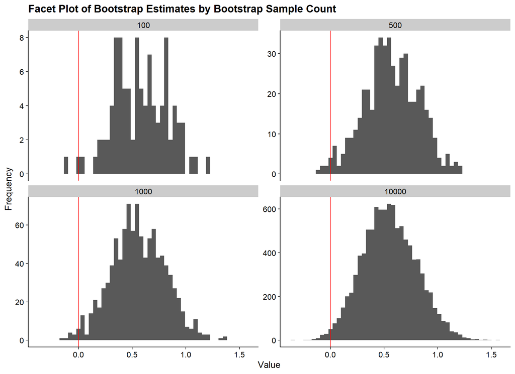

```r
ggplot(btstrp_stdnorm_10_mean_plots_tbl) +
  geom_histogram(aes(x = btstrp_mean), bins = 50) +
  geom_vline(aes(xintercept = 0), colour = 'red') +
  facet_wrap(vars(btstrp_size), scales = 'free_y') +
  xlab("Value") +
  ylab("Frequency") +
  ggtitle("Facet Plot of Bootstrap Estimates by Bootstrap Sample Count")
```

We see there is not much of an impact beyond 500.

#### 1.1.1.2 Sample Size $N=100$

We now repeat this procedure but with a larger sample size of 100.

```r
F_stdnorm_100_tbl <- F_stdnorm_tbl %>% head(100)

F_stdnorm_100_tbl %>% pull(x) %>% round(2)
```

```
##   [1]  1.37 -0.56  0.36  0.63  0.40 -0.11  1.51 -0.09  2.02 -0.06  1.30  2.29
##  [13] -1.39 -0.28 -0.13  0.64 -0.28 -2.66 -2.44  1.32 -0.31 -1.78 -0.17  1.21
##  [25]  1.90 -0.43 -0.26 -1.76  0.46 -0.64  0.46  0.70  1.04 -0.61  0.50 -1.72
##  [37] -0.78 -0.85 -2.41  0.04  0.21 -0.36  0.76 -0.73 -1.37  0.43 -0.81  1.44
##  [49] -0.43  0.66  0.32 -0.78  1.58  0.64  0.09  0.28  0.68  0.09 -2.99  0.28
##  [61] -0.37  0.19  0.58  1.40 -0.73  1.30  0.34  1.04  0.92  0.72 -1.04 -0.09
##  [73]  0.62 -0.95 -0.54  0.58  0.77  0.46 -0.89 -1.10  1.51  0.26  0.09 -0.12
##  [85] -1.19  0.61 -0.22 -0.18  0.93  0.82  1.39 -0.48  0.65  1.39 -1.11 -0.86
##  [97] -1.13 -1.46  0.08  0.65
```

```r
F_stdnorm_100_tbl %>% glimpse()
```

```
## Observations: 100
## Variables: 1
## $ x <dbl> 1.3709584, -0.5646982, 0.3631284, 0.6328626, 0.4042683, -0.106124...
```

As before, we calculate the sample mean for this sample size:

```r
F_stdnorm_100_tbl %>% pull(x) %>% mean()
```

```
## [1] 0.0325148
```

Now we need to calculate the bootstrap estimates for the mean - we have wrapped this logic into the function `construct_bootstrap_size_plots`

```r
boot_100_mean_tbl <- F_stdnorm_100_tbl %>%
  pull(x) %>%
  construct_bootstrap_size_plots(mean)

boot_100_mean_tbl %>%
  group_by(btstrp_size) %>%
  summarise(summ = list(summary(btstrp_val))) %>%
  unnest_wider(summ)
```

```
## # A tibble: 4 x 7
##   btstrp_size   Min. `1st Qu.` Median   Mean `3rd Qu.`  Max.
##         <dbl>  <dbl>     <dbl>  <dbl>  <dbl>     <dbl> <dbl>
## 1         100 -0.229   -0.0222 0.0393 0.0333    0.102  0.243
## 2         500 -0.288   -0.0339 0.0250 0.0287    0.0968 0.318
## 3        1000 -0.299   -0.0305 0.0334 0.0337    0.0979 0.415
## 4       10000 -0.354   -0.0381 0.0311 0.0313    0.0997 0.417
```

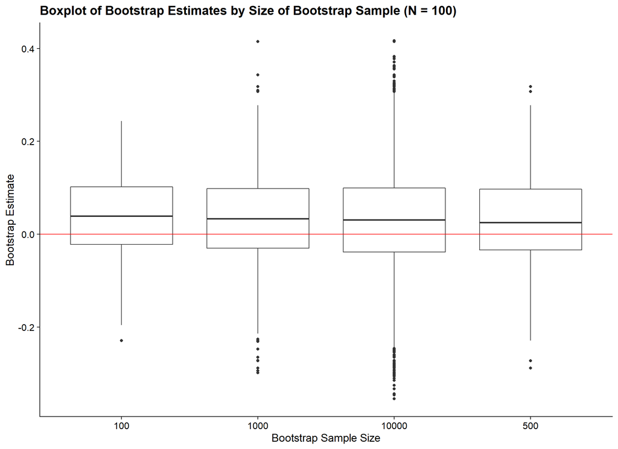

```r
ggplot(boot_100_mean_tbl) +
  geom_boxplot(aes(x = vec_cast(btstrp_size, character()), y = btstrp_val)) +
  geom_hline(aes(yintercept = 0), colour = 'red') +
  xlab("Bootstrap Sample Size") +
  ylab("Bootstrap Estimate") +
  ggtitle("Boxplot of Bootstrap Estimates by Size of Bootstrap Sample (N = 100)")
```

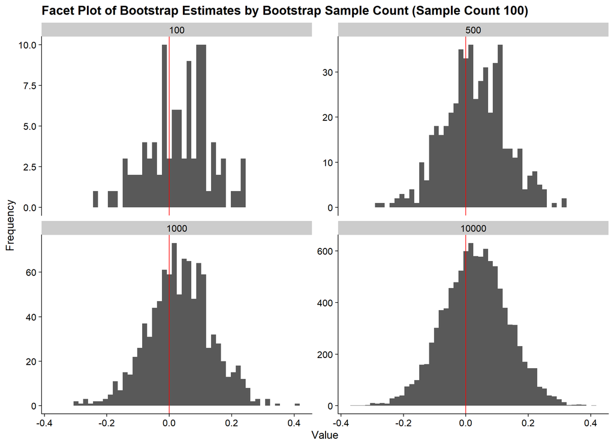

```r
ggplot(boot_100_mean_tbl) +
  geom_histogram(aes(x = btstrp_val), bins = 50) +
  geom_vline(aes(xintercept = 0), colour = 'red') +
  facet_wrap(vars(btstrp_size), scales = 'free_y') +
  xlab("Value") +
  ylab("Frequency") +
  ggtitle("Facet Plot of Bootstrap Estimates by Bootstrap Sample Count (Sample Count 100)")
```